# Network Must-Known Concepts

- Undirected / Directed, Connected / Disconnected, Weighted / Unweighted
- **Strongly Connected** vs **Directed Acyclic Graph**
- **Strongly Connected**: Any node can reach any other node via a directed path
- **Any directed graph $G(V,E)$ can be seemed as a directed acyclic graph $G^{'}(V^{'},E^{'})$ with $V^{'}$ are the strongly connected components of $G(V,E)$**

```python
import networkx as nx
import numpy as np
import matplotlib.pyplot as plt
import pylab
%matplotlib inline
```

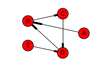

```python
G = nx.DiGraph()
G.add_edges_from([('A','B'),('B','C'),('C','D'),('D','B'),('E','D')])

plt.figure(figsize=(3,2))
plt.axis('off')
nx.draw_networkx(G, pos=nx.circular_layout(G), with_label=True, node_size=500)  # layout: positioning algorithms for graph drawing,
                                                                                # here use circular_layout,
plt.show()                                            # "arrows" for directed graph are drawn with just thicker stubs by default
```

```python
print list(nx.strongly_connected_components(G)), '\n', list(nx.weakly_connected_components(G)), '\n', nx.is_strongly_connected(G)

# draw all the strongly connected components
#for _ in nx.strongly_connected_component_subgraphs(G):
#    plt.figure(figsize=(2,1))
#    nx.draw(_)
```

```
[['B', 'C', 'D'], ['A'], ['E']]
[['A', 'C', 'B', 'E', 'D']]
False
```

- Adjacency Matrix, Sparse Graph, Complete Graph

  [A cool visualization of Adjacency Matrix](http://bost.ocks.org/mike/miserables/), select order by cluster and compare the matrix with [Another cool visualization of Network](http://bl.ocks.org/mbostock/4062045), see if you can find the corresponding group in the network for each block in the matrix, both visualization use [d3.js](http://d3js.org/) library and *Les Miserables* dataset.

```python
A = nx.adjacency_matrix(G).todense()  # adjacency_matrix returns a sparse matrix,
                                      # can be converted to dense matrix by A.todense() method
print G.nodes(), '\n\n', A, '\n\n'

# convert to undirected graph
print nx.adjacency_matrix(G.to_undirected()).todense()
```

```
['A', 'C', 'B', 'E', 'D']

[[0 0 1 0 0]
 [0 0 0 0 1]
 [0 1 0 0 0]
 [0 0 0 0 1]
 [0 0 1 0 0]]


[[0 0 1 0 0]
 [0 0 1 0 1]
 [1 1 0 0 1]
 [0 0 0 0 1]
 [0 1 1 1 0]]
```

- Degree Distribution, Clustering Coefficient, Distance

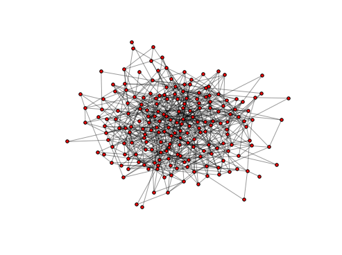

```python
# generate a random graph
G = nx.random_graphs.fast_gnp_random_graph(200, 0.03) # n: 200, p: 0.03, expected degree will be (n-1)p
pos = nx.spring_layout(G)
plt.figure(figsize=(8,6))
nx.draw_networkx_nodes(G, pos, node_size=20, with_labels=False)
nx.draw_networkx_edges(G, pos, alpha=0.4)
plt.axis('off')
plt.show()
```

```python
# import bokeh package for nice and interactive plot

# anaconda includes bokeh 0.6.1 by default, need to update it to 0.8.1 by
#
#       conda install bokeh
#

from bokeh.charts import Histogram
from bokeh.plotting import *
output_notebook()
```

BokehJS successfully loaded.

```python
degree_sequence = sorted(nx.degree(G).values(), reverse=True)

p1 = figure(title="Degrees", width=500, height=350)
p1.circle(range(len(degree_sequence)), degree_sequence, color="red")
p1.xaxis.axis_label = 'Node (after sorted)'
p1.yaxis.axis_label = 'Degree'

bins = np.arange(min(degree_sequence)-0.5, max(degree_sequence)+1, 1)

# using bokeh high-level charts interface
#hist = Histogram(degree_sequence, bins=max(degree_sequence)-1, ylabel="frequency",
#                 xlabel="degree", width=500, height=350, notebook=True)
#hist.show()

# using simple bokeh plot function
h, bins = np.histogram(degree_sequence, density=True, bins=bins)
#print degree_sequence,'\n',h,'\n',bins
p2 = figure(title="Degree Distribution", width=500, height=350)
p2.quad(top=h/sum(h), bottom=0, left=bins[:-1]+0.03, right=bins[1:]-0.03, alpha=0.6, fill_color="red", line_color="red")
p2.xaxis.axis_label = 'Degree'
p2.yaxis.axis_label = 'Frequency'
show(VBox(p1,p2))
```

[output not shown]

```python
clustering_sequence = sorted(nx.clustering(G).values(), reverse=True)
p1 = figure(title="Clustering Coefficients", width=500, height=350)
p1.circle(range(len(clustering_sequence)), clustering_sequence, color="green")
p1.xaxis.axis_label = 'Node (after sorted)'
p1.yaxis.axis_label = 'Clustering Coefficient'

p2 = figure(title="Clustering Coefficient Distribution", width=500, height=350)
bins = np.arange(min(clustering_sequence), max(clustering_sequence), 0.02)
h, bins = np.histogram(clustering_sequence, density=True, bins=bins)
#print h, bins, sum(h)
p2 = figure(title="Clustering Coefficient Distribution", width=500, height=350)
p2.quad(top=h/sum(h), bottom=0, left=bins[:-1]+0.0008, right=bins[1:]-0.0008, alpha=0.6, fill_color="red", line_color="red")
p2.xaxis.axis_label = 'Clustering Coefficient'
p2.yaxis.axis_label = 'Frequency'

show(VBox(p1,p2))
```

[output not shown]

- **Centrality Measures**
- Node centrality: How central/important/influential each node is?
  - Degree Centrality: **total number** of neighbors
  - Betweenness Centrality / Katz Centrality: **total number** of shortest paths / paths that goes through
  - Closeness Centrality: 1/(**total length** of distances to all the other nodes)
  - Eigenvector Centrality: **total centrality** of neighbors **+** centrality should be **self consistant / balanced**, $A\mathbf{x} = \lambda \mathbf{x}$. Algorithm Understanding: suppose $\mathbf{v}_i$ is $i$th eigenvector of $A$, and $\mathbf{v}_i^{max}$ is the eigenvector with maximum absolute eigenvalue (mathematically called spectral radius), $\mathbf{x} = \sum_{i}c_i\mathbf{v}_i$ is the expansion of $\mathbf{x}$ in the eigenspace of $A$, so $A^k\mathbf{x} = \sum_{i}c_i\lambda_i^{k}\mathbf{v}_i$, then for any vector $\mathbf{x}$ that is not orthogonal with $\mathbf{v}_i^{max}$, which means $c_i^{max} \neq 0$, $A^k$ act on $\mathbf{x}$ is equal to first project $\mathbf{x}$ into eigenspace of $A$, then keep rescaling each component $c_i\lambda_i^{k-1}\mathbf{v}_i$ by corresponding eigenvalue $\lambda_i$, when $k\to \infty$, the component in $\mathbf{v}_i^{max}$ direction will dominate. Normalization step is to avoid blowing up from $\lambda_i^k$. But why we choose the eigenvector with maximum eigenvalue as the centrality measure instead of any eigenvector? 1, Assumption of each element in $\mathbf{x}$ should be $\gt 0$; 2, [Perron–Frobenius theorem](http://en.wikipedia.org/wiki/Perron–Frobenius_theorem).
- Normalization: **total number** -> **total number / maximum total number**, **total length** -> **total length / minimum total length**
- Network centralization: How central the most central node is in relation to how central all the other nodes are? An extension can be how much variation/heterogeneity the network has? Every node centrality measure has a corresponding centralization measure.

# Network Models

- [Small World](http://en.wikipedia.org/wiki/Small-world_network): average path length for social networks, 6-degree.

Stanley Milgram's Experiment:

[figure not shown]

- Model Comparison:

[output not shown]

# Visualization of Networks

- Links: [Social network analysis software](http://en.wikipedia.org/wiki/Social_network_analysis_software). [Gephi](http://gephi.github.io/): [Wiki Page](http://wiki.gephi.org/index.php/Main_Page), [User Manual](http://wiki.gephi.org/index.php/Gephi_User_Manual), [Features](http://gephi.github.io/features/). [D3.js](http://d3js.org/): [Gallery1](http://biovisualize.github.io/d3visualization/) [Gallery2](http://christopheviau.com/d3list/gallery.html) [Gallery3](https://github.com/mbostock/d3/wiki/Gallery), [Digging into newtorkx and d3](http://blogger.ghostweather.com/2012/03/digging-into-networkx-and-d3.html), [visualizing networks](http://www.bostondatafest.com/wp-content/uploads/2014/11/cherny_short_networks_vis.pdf), [Q: how to animate growth of social network?](http://datascience.stackexchange.com/questions/176/how-to-animate-growth-of-a-social-network), [**Introduction to Network Analysis and Representation**](http://dhs.stanford.edu/dh/networks/)